# Predicting outcome from Human Activity Recognition dataset

Manos Antoniou

Thursday, April 23, 2015

## Introduction

Human Activity Recognition has emerged as a key research area in the last years and is gaining increasing attention by the pervasive computing research, especially for the development of context-aware systems. There are many potential applications for HAR <sup>1</sup>.  
Using devices such as Jawbone Up, Nike FuelBand, and Fitbit it is now possible to collect a large amount of data about human activity relatively inexpensively. These type of devices are part of the quantified self movement – a group of enthusiasts who take measurements about themselves regularly to improve their health, to find patterns in their behaviour, or because they are tech geeks. One thing that people regularly do is quantify how much of a particular activity they do, but they rarely quantify how well they do it.  
Particularly in this project, the investigated dataset is collected from accelerometers on the belt, forearm, arm, and dumbell of 6 participants. They were asked to perform barbell lifts correctly and incorrectly in 5 different ways.

- Exactly according to the specification (Class A)
- Throwing the elbows to the front (Class B)
- Lifting the dumbbell only halfway (Class C)
- Lowering the dumbbell only halfway (Class D)
- Throwing the hips to the front (Class E)

The goal is to predict the **manner in which they did the exercise**.

## Methods

### Exploratory Analysis

At first it is important to import the training and testing dataset

```r
library(ggplot2)
library(ElemStatLearn)
library(caret)
library(randomForest)
library(rattle)
library(rpart.plot)

setwd("C:/Dropbox/Projects/R/Environment")
# Check if zip file exists on working directory and if not, it downloads it
if (!file.exists("pml-training.csv")) {
        fileUrl <- "https://d396qusza40orc.cloudfront.net/predmachlearn/pml-training.csv"
        download.file(fileUrl, destfile="./pml-training.csv")
}

if (!file.exists("pml-testing.csv")) {
        fileUrl <- "https://d396qusza40orc.cloudfront.net/predmachlearn/pml-testing.csv"
        download.file(fileUrl, destfile="./pml-testing.csv")
}

# Insert the training and testing datasets by assigning NA to all null values
training <- read.csv("pml-training.csv", header = TRUE, sep = ",", quote = "\"", na.strings=c("NA",""))
testing <- read.csv("pml-testing.csv", header = TRUE, sep = ",", quote = "\"", na.strings=c("NA",""))
```

```r
# Create a dataframe with the sum of missing values per column
training.na <- as.data.frame(apply(X=training,2,FUN=function(x) length(which(is.na(x)))))
names(training.na) <- "Missing Values"
training.na
```

```
##                          Missing Values
## X                                     0
## user_name                             0
## raw_timestamp_part_1                  0
## raw_timestamp_part_2                  0
## cvtd_timestamp                        0
## new_window                            0
## num_window                            0
## roll_belt                             0
## pitch_belt                            0
## yaw_belt                              0
## total_accel_belt                      0
## kurtosis_roll_belt                19216
## kurtosis_picth_belt               19216
## kurtosis_yaw_belt                 19216
## skewness_roll_belt                19216
## skewness_roll_belt.1              19216
## skewness_yaw_belt                 19216
## max_roll_belt                     19216
## max_picth_belt                    19216
## max_yaw_belt                      19216
## min_roll_belt                     19216
## min_pitch_belt                    19216
## min_yaw_belt                      19216
## amplitude_roll_belt               19216
## amplitude_pitch_belt              19216
## amplitude_yaw_belt                19216
## var_total_accel_belt              19216
## avg_roll_belt                     19216
## stddev_roll_belt                  19216
## var_roll_belt                     19216
## avg_pitch_belt                    19216
## stddev_pitch_belt                 19216
## var_pitch_belt                    19216
## avg_yaw_belt                      19216
## stddev_yaw_belt                   19216
## var_yaw_belt                      19216
## gyros_belt_x                          0
## gyros_belt_y                          0
## gyros_belt_z                          0
```

[output cut: 106 more lines]

```
## stddev_pitch_forearm              19216
## var_pitch_forearm                 19216
## avg_yaw_forearm                   19216
## stddev_yaw_forearm                19216
## var_yaw_forearm                   19216
## gyros_forearm_x                       0
## gyros_forearm_y                       0
## gyros_forearm_z                       0
## accel_forearm_x                       0
## accel_forearm_y                       0
## accel_forearm_z                       0
## magnet_forearm_x                      0
## magnet_forearm_y                      0
## magnet_forearm_z                      0
## classe                                0
```

```r
# Keep just the non NA's columns
training1 <- training[,colSums(is.na(training)) < 2]

# Delete the first 7 columns, because they are not necessary
training1 <- training1[,8:60]

# Apply the column reduction to the testing dataset as well
testing1 <- testing[,names(training1[,1:52])]
```

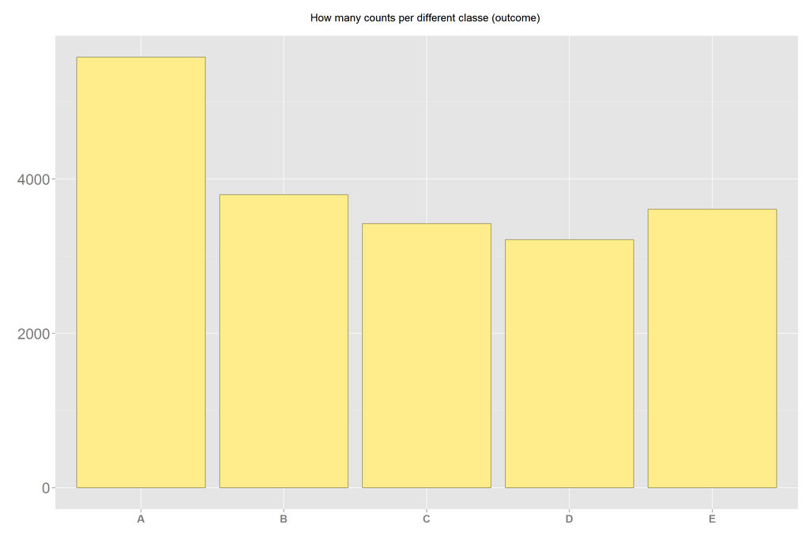

### Statistical Inference & Modelling

I chose two different approaches for developing the algorithm. The first one is classification trees <sup>2</sup> (method = rpart) and the second is to use the random forest <sup>3</sup> algorithm.  
The fist prediction model was build by using the rpart method of the caret package. Then we ploted the decision tree.

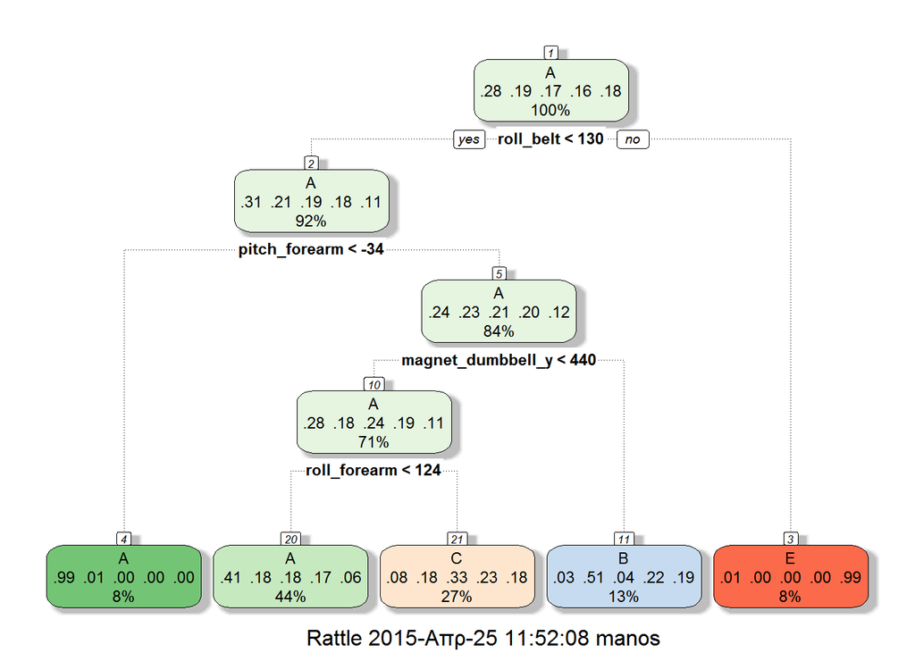

```r
# Apply a prediction Model with all variables
model.all <- train(classe ~ ., method="rpart", data = training1)

# Plot the model
fancyRpartPlot(model.all$finalModel)
```

In order to check the accuracy rate of the model, we print the confusion Matrix. The accuracy rate **(around 50%) is low**, so a further investigation is necessary.

```r
# Apply the prediction
prediction <- predict(model.all, newdata= training1)
# Check the accuracy of the  prediction model
print(confusionMatrix(prediction, training1$classe), digits=4)
```

```
## Confusion Matrix and Statistics
##
##           Reference
## Prediction    A    B    C    D    E
##          A 5080 1581 1587 1449  524
##          B   81 1286  108  568  486
##          C  405  930 1727 1199  966
##          D    0    0    0    0    0
##          E   14    0    0    0 1631
##
## Overall Statistics
##
##                Accuracy : 0.4956
##                  95% CI : (0.4885, 0.5026)
##     No Information Rate : 0.2844
##     P-Value [Acc > NIR] : < 2.2e-16
##
##                   Kappa : 0.3407
##  Mcnemar's Test P-Value : NA
##
## Statistics by Class:
##
##                      Class: A Class: B Class: C Class: D Class: E
## Sensitivity            0.9104  0.33869  0.50468   0.0000  0.45218
## Specificity            0.6339  0.92145  0.78395   1.0000  0.99913
## Pos Pred Value         0.4970  0.50850  0.33040      NaN  0.99149
## Neg Pred Value         0.9468  0.85310  0.88225   0.8361  0.89008
## Prevalence             0.2844  0.19351  0.17440   0.1639  0.18382
## Detection Rate         0.2589  0.06554  0.08801   0.0000  0.08312
## Detection Prevalence   0.5209  0.12889  0.26638   0.0000  0.08383
## Balanced Accuracy      0.7721  0.63007  0.64431   0.5000  0.72565
```

It seems that a good idea is to use **cross validation** in order to achieve more accurate results. Since we have a large training set (19622 obs) we can split it in **10 equal datasets** (around 1960 observations each)

```r
# Create 10 sets of data
set.seed(1)
ids <- createDataPartition(y=training1$classe, p=1/10, list=FALSE)
group1 <- training1[ids,]
remain1 <- training1[-ids,]

set.seed(1)
ids <- createDataPartition(y=remain1$classe, p=1/9, list=FALSE)
group2 <- remain1[ids,]
remain1 <- remain1[-ids,]

set.seed(1)
ids <- createDataPartition(y=remain1$classe, p=1/8, list=FALSE)
group3 <- remain1[ids,]
remain1 <- remain1[-ids,]

set.seed(1)
ids <- createDataPartition(y=remain1$classe, p=1/7, list=FALSE)
group4 <- remain1[ids,]
remain1 <- remain1[-ids,]

set.seed(1)
ids <- createDataPartition(y=remain1$classe, p=1/6, list=FALSE)
group5 <- remain1[ids,]
remain1 <- remain1[-ids,]

set.seed(1)
ids <- createDataPartition(y=remain1$classe, p=1/5, list=FALSE)
group6 <- remain1[ids,]
remain1 <- remain1[-ids,]

set.seed(1)
ids <- createDataPartition(y=remain1$classe, p=1/4, list=FALSE)
group7 <- remain1[ids,]
remain1 <- remain1[-ids,]

set.seed(1)
ids <- createDataPartition(y=remain1$classe, p=1/3, list=FALSE)
group8 <- remain1[ids,]
remain1 <- remain1[-ids,]

set.seed(1)
ids <- createDataPartition(y=remain1$classe, p=1/2, list=FALSE)
group9 <- remain1[ids,]
group10 <- remain1[-ids,]
```

Now we apply the random forest algorithm in order to build our prediction model for the first group dataset (group1). The **“in the sample error”** is almost **0%**, which is great but it may indicates overfitting. It is important to check the **out of sample error** as well.

```r
# Apply a prediction Model with all variables
set.seed(1)
model.rm <- randomForest(classe ~ ., data = group1, importance = FALSE)

# Apply the prediction
prediction <- predict(model.rm, newdata= group1)

# Check the accuracy of the  prediction model
print(confusionMatrix(prediction, group1$classe), digits=4)
```

```
## Confusion Matrix and Statistics
##
##           Reference
## Prediction   A   B   C   D   E
##          A 558   0   0   0   0
##          B   0 380   0   0   0
##          C   0   0 343   0   0
##          D   0   0   0 322   0
##          E   0   0   0   0 361
##
## Overall Statistics
##
##                Accuracy : 1
##                  95% CI : (0.9981, 1)
##     No Information Rate : 0.2841
##     P-Value [Acc > NIR] : < 2.2e-16
##
##                   Kappa : 1
##  Mcnemar's Test P-Value : NA
##
## Statistics by Class:
##
##                      Class: A Class: B Class: C Class: D Class: E
## Sensitivity            1.0000   1.0000   1.0000    1.000   1.0000
## Specificity            1.0000   1.0000   1.0000    1.000   1.0000
## Pos Pred Value         1.0000   1.0000   1.0000    1.000   1.0000
## Neg Pred Value         1.0000   1.0000   1.0000    1.000   1.0000
## Prevalence             0.2841   0.1935   0.1746    0.164   0.1838
## Detection Rate         0.2841   0.1935   0.1746    0.164   0.1838
## Detection Prevalence   0.2841   0.1935   0.1746    0.164   0.1838
## Balanced Accuracy      1.0000   1.0000   1.0000    1.000   1.0000
```

The average **“out of sample error”** is around **4.3 %**. In each of the datasets the error rate varies from 3-5 %, but the average is 4.3 % which is quite low.

```r
# Create a vector with the names of the datasets
datasets <- c("group2", "group3", "group4", "group5", "group6", "group7","group8",
              "group9","group10")

# Create a vector with the estimated error rate of each dataset
error.rate <- c(1-mean(predict(model.rm, newdata= group2) == group2$classe),
                1-mean(predict(model.rm, newdata= group3) == group3$classe),
                1-mean(predict(model.rm, newdata= group4) == group4$classe),
                1-mean(predict(model.rm, newdata= group5) == group5$classe),
                1-mean(predict(model.rm, newdata= group6) == group6$classe),
                1-mean(predict(model.rm, newdata= group7) == group7$classe),
                1-mean(predict(model.rm, newdata= group8) == group8$classe),
                1-mean(predict(model.rm, newdata= group9) == group9$classe),
                1-mean(predict(model.rm, newdata= group10) == group10$classe))

# Create and print a table of out of sample error rates
outofsample  <- as.data.frame(cbind(datasets,error.rate))
outofsample
```

```
##   datasets         error.rate
## 1   group2 0.0346232179226069
## 2   group3 0.0397350993377483
## 3   group4 0.0376974019358125
## 4   group5 0.0397350993377483
## 5   group6 0.0529801324503312
## 6   group7 0.0494393476044852
## 7   group8 0.0459183673469388
## 8   group9 0.0443877551020408
## 9  group10 0.0464285714285714
```

```r
# Print the average error rate.
mean(as.numeric(as.character(outofsample$error.rate)))
```

```
## [1] 0.04343833
```

## Results & Conclusions

So finally, after attempting with 2 different ways to build a model to predict the the manner in which they did the exercise we concluded that the **random forest algorithm is the best one to use**. This prediction model has an **out of sample error of 4.3%** which is acceptable.  
In the future, we could try to improve this model by e.g. reduce the oveffiting. The **“in the sample”** error rate is 0 which indicates some overfitting. If we managed to have a slighter higher error rate then the out of sample error rate may decreased further.

## References

1. http://groupware.les.inf.puc-rio.br/har
2. http://en.wikipedia.org/wiki/Decision_tree_learning
3. http://en.wikipedia.org/wiki/Random_forest